# Ошибки I и II рода

## Требования к сдаче и оформлению задания

Заполните этот qmd-файл кодом и ответами. Порядок сдачи задания описан в README.md, на Stepik или Google-class.

1. Старайтесь соблюдать единый стиль оформления и структуру отчёта. Не оставляйте лишние чанки кода, текст или комментарии, которые не относятся к решению задания.
2. Основные результаты представьте на графиках и объясните в тексте. Отдельные таблицы результатов не требуются. Не оставляйте необработанный консольный вывод или отдельные числа без пояснений.
3. Графики должны быть достаточно крупными, с читаемыми русскими подписями, содержательным заголовком и правильно названными осями. Не используйте фон ggplot2 по умолчанию.
4. Ответы на вопросы и интерпретации результатов, включая графики, пишите обычным текстом, а не комментариями к коду. Код и его вывод не заменяют ответ на вопрос.
5. Сохраняйте исходную структуру проекта в репозитории. Не добавляйте лишние файлы, которые не относятся к проекту или выполнению заданий.
6. Оформление коммитов и веток на GitHub должно соответствовать общим правилам для всех курсов Института биоинформатики.

## О задании

На занятии мы оценивали ошибки I и II рода. Теперь с помощью симуляций вы **графически исследуете**, как вероятности этих ошибок у двухвыборочного t-теста зависят от уровня значимости, объёма выборки и распределения данных.

Для этого вы проведёте серии симуляций для разных **сочетаний параметров**.

**Результат выполнения домашнего задания: шесть графиков зависимости ошибки I или II рода от $\alpha$ и их интерпретация, выводы.**

## Условия

> Если условия не будут понятны с первого раза, то посмотрите на таблицу в разделе **“Сочетания условий”**.
1. Для сравнения средних двух независимых групп используйте `t.test()`.
2. Объём выборки в каждой из двух групп ($X$ и $Y$) должен быть одинаковым: **$n$ = 3, 10, 30, 100**. Здесь $n$ – объём **одной** выборки. В одном повторении сравниваются две выборки, то есть всего $2n$ наблюдений.
3. Исследуйте **нормальное, равномерное и экспоненциальное распределения**.
4. Проверяйте гипотезы $H_0: \mu_X = \mu_Y$ и $H_a: \mu_X \ne \mu_Y$. Для каждого типа распределения и объёма выборки рассмотрите два сценария:
- **$H_0$ верна:** генерируйте две независимые выборки из распределения с одинаковыми параметрами для обеих групп. Средние генеральных совокупностей равны.
- **$H_0$ неверна:** генерируйте две независимые выборки из распределений выбранного типа, выбрав параметры так, чтобы средние генеральных совокупностей различались.

> **Параметры распределений выберите один раз для каждого типа распределения и сценария.** В отчёте укажите выбранные параметры, истинные средние и истинные стандартные отклонения обеих групп. Затем сохраняйте параметры при изменении $n$ и $\alpha$.

> Рекомендуем для разных типов распределений задать одинаковое истинное среднее группы $X$ и одинаковое истинное среднее группы $Y$ в соответствующем сценарии.
5. Используйте уровни значимости **$\alpha = 0.01, 0.02, \ldots, 0.20$ с шагом 0.01**.
6. Для каждого сочетания типа распределения, объёма выборки и сценария проведите одну серию из **1000 повторений**. Вероятность ошибки оценивайте по её частоте в серии.

### Сочетания условий

**Переберите все сочетания:** 2 сценария × 3 типа распределений × 4 объёма выборки × 20 уровней значимости. В ячейках указан диапазон $\alpha$.

| Сценарий | Тип распределения | $n = 3$ | $n = 10$ | $n = 30$ | $n = 100$ |
| --- | --- | --- | --- | --- | --- |
| **$H_0$ верна** | Нормальное | $[0.01, 0.20]$ | $[0.01, 0.20]$ | $[0.01, 0.20]$ | $[0.01, 0.20]$ |
|  | Равномерное | $[0.01, 0.20]$ | $[0.01, 0.20]$ | $[0.01, 0.20]$ | $[0.01, 0.20]$ |
|  | Экспоненциальное | $[0.01, 0.20]$ | $[0.01, 0.20]$ | $[0.01, 0.20]$ | $[0.01, 0.20]$ |
| **$H_0$ неверна** | Нормальное | $[0.01, 0.20]$ | $[0.01, 0.20]$ | $[0.01, 0.20]$ | $[0.01, 0.20]$ |
|  | Равномерное | $[0.01, 0.20]$ | $[0.01, 0.20]$ | $[0.01, 0.20]$ | $[0.01, 0.20]$ |
|  | Экспоненциальное | $[0.01, 0.20]$ | $[0.01, 0.20]$ | $[0.01, 0.20]$ | $[0.01, 0.20]$ |

Каждая ячейка с диапазоном $\alpha$ соответствует одной серии из **1000 повторений** для указанного сценария, типа распределения и объёма выборки. **Один и тот же набор p-значений этой серии используйте для всех 20 уровней $\alpha$: новые выборки для каждого $\alpha$ генерировать не нужно.**

Всего получится **24 серии**. Для каждой серии оцените вероятность ошибки I или II рода (в зависимости от сценария) при всех **20 уровнях $\alpha$**. В результате получите по **240 оценок для каждого типа ошибки (сценария)**.

## Проведение симуляции

1. **Задайте seed один раз перед симуляциями**.
2. В каждом повторении генерируйте две новые независимые выборки, применяйте t-тест и сохраняйте p-значение.
3. Проведите симуляции и сохраните оценки вероятностей ошибок I или II рода для каждого сочетания типа распределения, объёма выборки, сценария и уровня значимости.

```r
library(ggplot2)
set.seed(20240501)
alphas <- seq(from = 0.01, to = 0.20, by = 0.01)
ns <- c(3, 10, 30, 100)
dists <- c("normal", "uniform", "exponential")
B <- 1000

results <- data.frame(
  scenario = character(),
  dist = character(),
  n = numeric(),
  alpha = numeric(),
  error_type = character(),
  error_prob = numeric(),
  stringsAsFactors = FALSE
)

for (scen in c("H0", "H1")) {
  for (dist in dists) {
    for (n in ns) {
      if (dist == "normal") {
        if (scen == "H0") {
          mean_x <- 1
          mean_y <- 1
        } else {
          mean_x <- 1
          mean_y <- 3
        }
        sd_x <- 1
        sd_y <- 1
      }

      if (dist == "uniform") {
        if (scen == "H0") {
          min_x <- 0
          max_x <- 2
          min_y <- 0
          max_y <- 2
        } else {
          min_x <- 0
          max_x <- 2
          min_y <- 2
          max_y <- 4
        }
      }

      if (dist == "exponential") {
        if (scen == "H0") {
          rate_x <- 1
          rate_y <- 1
        } else {
          rate_x <- 1
          rate_y <- 1 / 3
        }
      }

      pvals <- numeric(B)

      for (i in 1:B) {
        if (dist == "normal") {
          x <- rnorm(n, mean = mean_x, sd = sd_x)
        } else if (dist == "uniform") {
          x <- runif(n, min = min_x, max = max_x)
        } else {
          x <- rexp(n, rate = rate_x)
        }

        if (dist == "normal") {
          y <- rnorm(n, mean = mean_y, sd = sd_y)
        } else if (dist == "uniform") {
          y <- runif(n, min = min_y, max = max_y)
        } else {
          y <- rexp(n, rate = rate_y)
        }

        test <- t.test(x, y)
        pvals[i] <- test$p.value
      }

      for (a in alphas) {
        reject_rate <- mean(pvals < a)

        if (scen == "H0") {
          error_prob <- reject_rate
          error_type <- "I рода"
        } else {
          error_prob <- 1 - reject_rate
          error_type <- "II рода"
        }

        results <- rbind(
          results,
          data.frame(
            scenario = scen,
            dist = dist,
            n = n,
            alpha = a,
            error_type = error_type,
            error_prob = error_prob
          )
        )
      }
    }
  }
}

head(results)
```

```
  scenario   dist n alpha error_type error_prob
1       H0 normal 3  0.01     I рода      0.008
2       H0 normal 3  0.02     I рода      0.018
3       H0 normal 3  0.03     I рода      0.020
4       H0 normal 3  0.04     I рода      0.025
5       H0 normal 3  0.05     I рода      0.039
6       H0 normal 3  0.06     I рода      0.045
```

```r
nrow(results)
```

```
[1] 480
```

## Постройте графики

1. Постройте шесть графиков: **три распределения × два типа ошибок**. Допустимы шесть отдельных рисунков или один общий рисунок из шести панелей.
2. На каждом графике по оси **X** отложите $\alpha$, по оси **Y** – вероятность ошибки I или II рода. Покажите **четыре кривые**, соответствующие объёмам выборки $n = 3, 10, 30, 100$.
3. Используйте одинаковые цвета для одинаковых $n$ и одинаковые границы осей для одного типа ошибки.

> На графиках для ошибки I рода добавьте пунктирную линию **$y = \alpha$** для сравнения с заданным уровнем значимости.

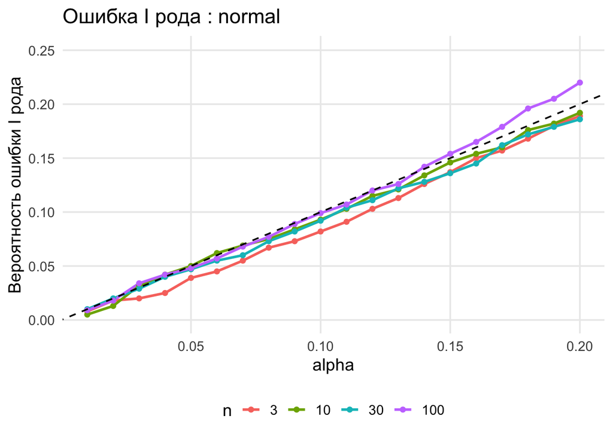

```r
sub_I <- results[results$error_type == "I рода", ]
sub_II <- results[results$error_type == "II рода", ]

ylim_I <- c(0, max(sub_I$error_prob) * 1.1)
ylim_II <- c(0, 1)

make_plot <- function(dist_name, err_type) {
  sub <- results[results$dist == dist_name & results$error_type == err_type, ]

  sub$n_f <- factor(sub$n, levels = c(3, 10, 30, 100))

  if (err_type == "I рода") {
    y_lab <- "Вероятность ошибки I рода"
  } else {
    y_lab <- "Вероятность ошибки II рода"
  }

  p <- ggplot(sub, aes(x = alpha, y = error_prob, color = n_f)) +
    geom_line(size = 1) +
    geom_point(size = 1.5) +
    labs(
      title = paste("Ошибка", err_type, ":", dist_name),
      x = "alpha",
      y = y_lab,
      color = "n"
    ) +
    theme_minimal(base_size = 14) +
    theme(
      legend.position = "bottom",
      panel.grid.minor = element_blank()
    )

  if (err_type == "I рода") {
    p <- p +
      geom_abline(intercept = 0, slope = 1, linetype = "dashed") +
      coord_cartesian(ylim = ylim_I)
  } else {
    p <- p + coord_cartesian(ylim = ylim_II)
  }

  return(p)
}

print(make_plot("normal", "I рода"))
```

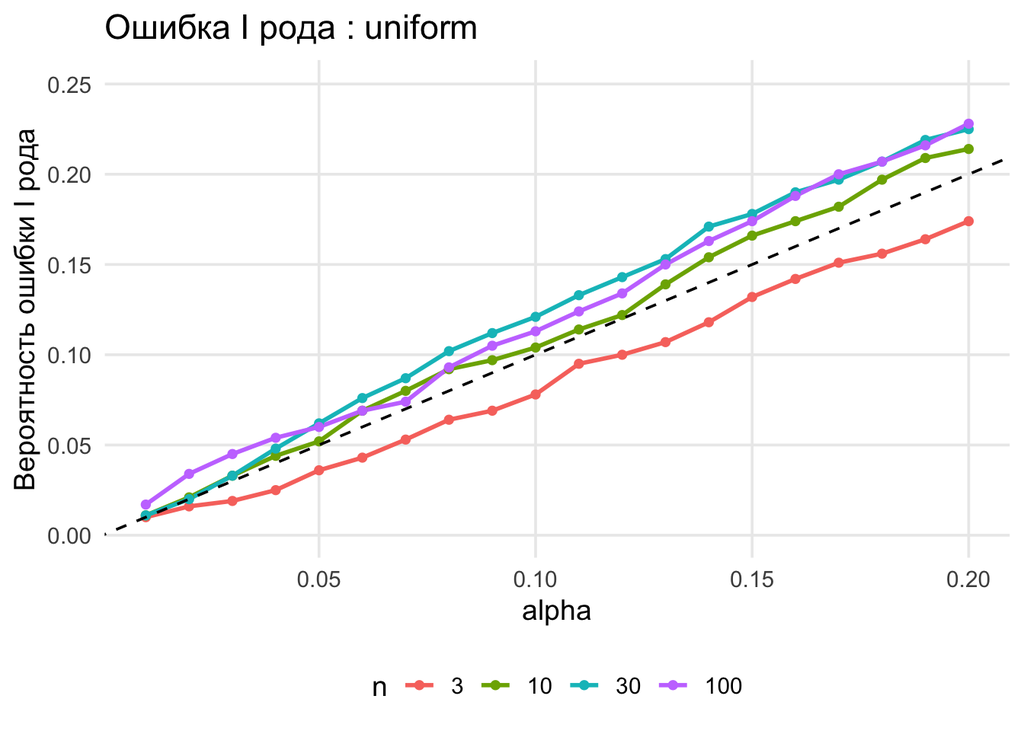

```r
print(make_plot("uniform", "I рода"))
```

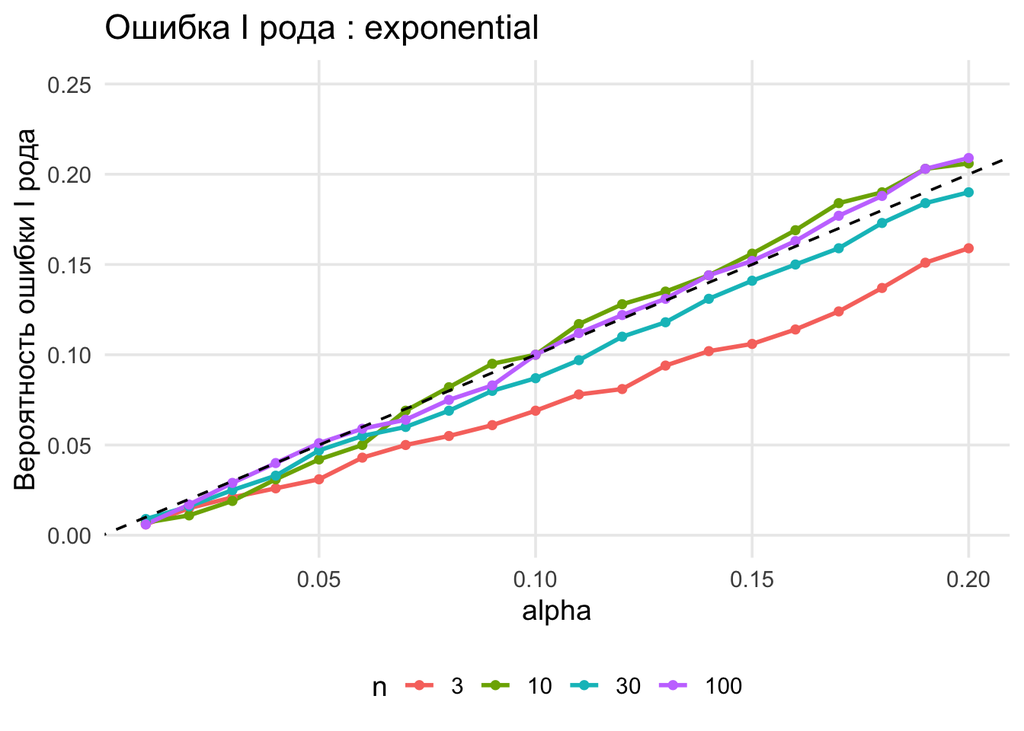

```r
print(make_plot("exponential", "I рода"))
```

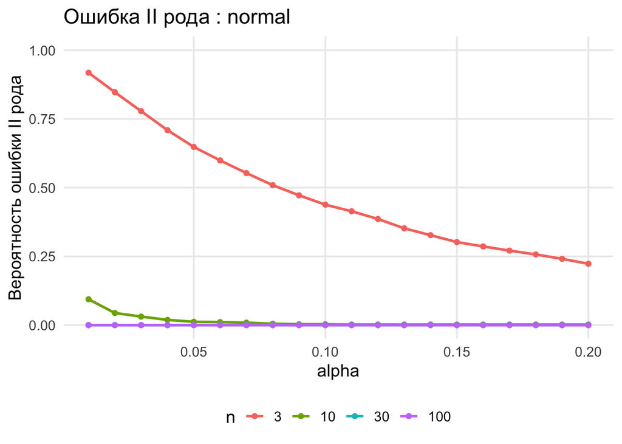

```r
print(make_plot("normal", "II рода"))
```

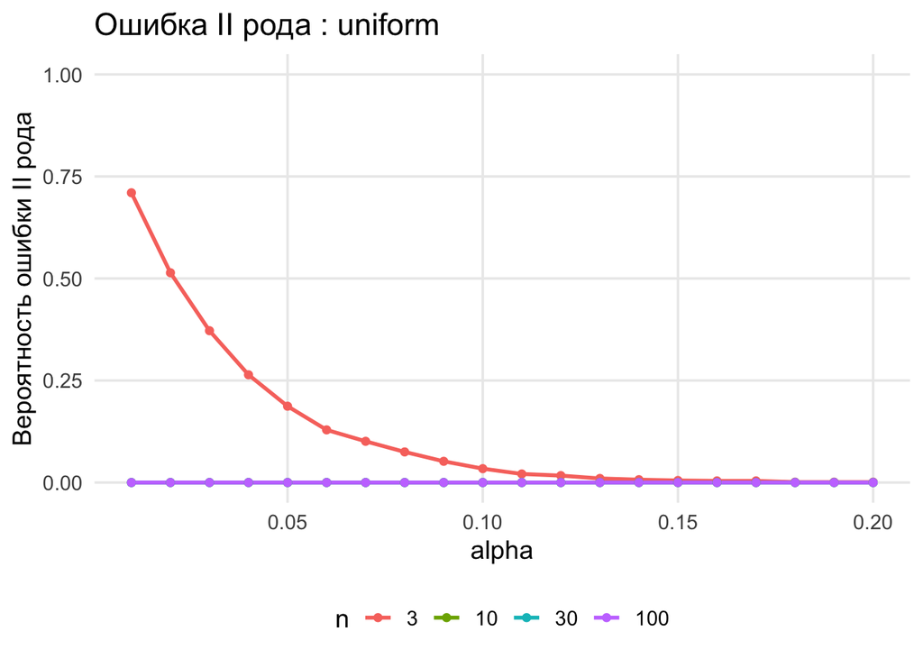

```r
print(make_plot("uniform", "II рода"))
```

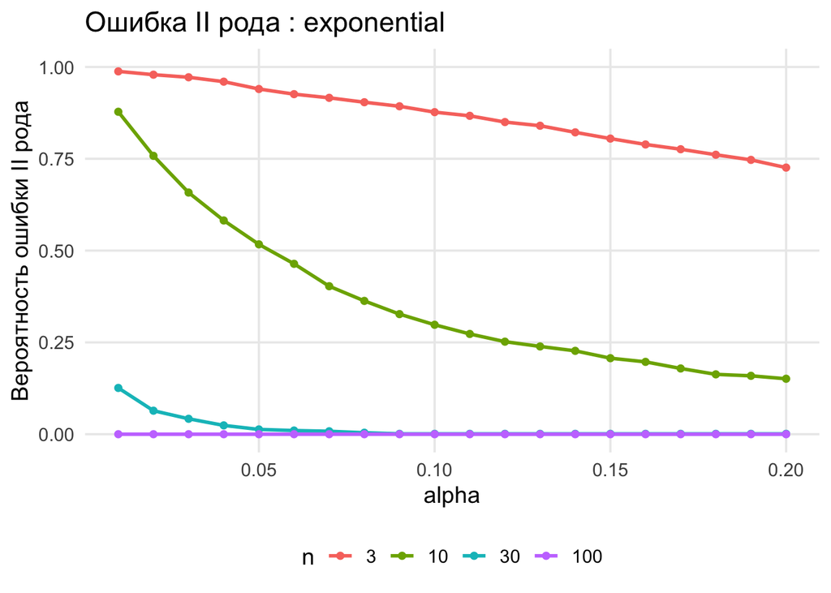

```r
print(make_plot("exponential", "II рода"))
```

## Выводы

Напишите выводы, попутно ответив на вопросы:

1. Насколько оценённая вероятность ошибки I рода близка к $\alpha$ в каждом случае? Видны ли отклонения для каких-либо распределений и объёмов выборки? Если видны, в какую сторону?
2. Как меняется вероятность ошибки II рода при изменении $\alpha$ и $n$? Как вы думаете, почему?
3. Чем различаются результаты для трёх распределений?
4. Почему оценённая частота ошибки I рода может не совпадать с $\alpha$?

Ошибка II рода убывает с ростом α, потому что чем выше уровень значимости, тем легче отвергнуть нулевую гипотезу, и мощность растёт. То же самое происходит с ростом n: стандартная ошибка разности средних уменьшается как корень из n, t-статистика становится больше, и тест увереннее обнаруживает истинное различие средних.

Распределения различаются между собой не столько по ошибке I рода, сколько по мощности при альтернативе. У равномерного распределения σ мало (≈ 0.577 в обеих группах), шум наименьший, поэтому мощность самая высокая и ошибка II рода самая низкая. У экспоненциального при альтернативе группа Y имеет σ = 3, шум в несколько раз больше, поэтому мощность самая низкая, а ошибка II рода самая высокая. Нормальное распределение занимает промежуточное положение.

## Дополнительное задание

Выберите один тип распределения и объём выборки $n=10$. Для каждого из двух сценариев возьмите параметры из основного задания и рассмотрите ещё два варианта, изменяя один выбранный параметр распределения. Укажите, какой параметр и в какой группе или группах вы изменяете.

Остальные параметры распределения, объём выборки, уровни $\alpha$ и число повторений оставьте прежними.

**Постройте два графика**: для ошибки I рода и для ошибки II рода. На каждом покажите три кривые – исходный вариант (из основного задания) и два изменённых.

Какие изменения вы наблюдаете? Почему?